# Machine Learning

Felipe Macias

21/02/2015

#### Repository on github: https://github.com/fmacias64/MachineLearning

# Synopsis

Using data sets provided by Groupware@LES (http://groupware.les.inf.puc-rio.br/har) a machine learning prediction model will be given for predicting the manner in which they did the exercise. The variable classe in the data set will be predicted.

# Work to be done

we’ll proceed in the following manner:

- Obtaining the Data, for training and test sets
- Cleaning Data:
  - Getting rid of columns with : high ocurrence of “NA”or null strings, NearZeroVariance, “#DIV/0”
  - Removing highly correlated features
  - Supressed columns in training set, would be supressed also on the test set
- Configuring traincontrol for repeated cross validation.
- Training & predicting with Boost method and cross validation
- Presenting confussion matrix, important variables

## Obtaining the data

Datasets are downloaded from these liks:

-https://d396qusza40orc.cloudfront.net/predmachlearn/pml-training.csv -https://d396qusza40orc.cloudfront.net/predmachlearn/pml-testing.csv

```r
training <- read.csv("/home/felipe/Dropbox/Coursera/MachineLearning_JohnHopkins/pml-training.csv", na.strings=c("", "NA", "#DIV/0!"),header=T, quote="\"", sep=",")

test <- read.csv("/home/felipe/Dropbox/Coursera/MachineLearning_JohnHopkins/pml-testing.csv", na.strings=c("", "NA", "#DIV/0!"),header=T, quote="\"", sep=",")
```

## Cleanning Data:

1.-Supressing features with high frequency of “NA” on training and test.

2.- Supressing non contributing features.

3.- Finding near zero variance columns.

4.- Removing highly correlated features

```r
library(caret)
#1
novan=apply(training, 2, function(x) sum(is.na(x)) > 0.9  || sum(x=="") > 0.9)
training<-training[,!novan]
test<-test[,!novan]

#2 Non interesting columns
training<-training[,c(-1:-7)]
test<-test[,c(-1:-7)]
#3 supressin near zoro variance
varianza_cero <- nearZeroVar(training, saveMetrics = TRUE)
training <- training[ , varianza_cero$nzv==FALSE]
test <- test[ , varianza_cero$nzv==FALSE]

#4 removing highly correlated columns
M <- abs(cor(training[,-dim(training)[2]]))
diag(M) <- 0
correlated<-findCorrelation(M, verbose = FALSE , cutoff = .95)
training<-training[,-correlated]
test<-test[,-correlated]
```

Boosting method will be used, with repeated cross validation of 5 folds and 2 repetitions:

```r
library(survival)
library(splines)
library(plyr)
library(gbm)
inTrain = createDataPartition(training$classe, p = 0.8, list=FALSE)
trainingCV1 <- training[inTrain,]
trainingCV2 <- training[-inTrain,]

fitControl <- trainControl(method = "repeatedcv",number = 5,repeats = 2)

set.seed(322)

modFit <- train(classe ~ ., method="gbm",trControl=fitControl,data=trainingCV1,verbose=FALSE)
```

Our resulting model :

```r
trellis.par.set(caretTheme())

print(modFit)
```

```
## Stochastic Gradient Boosting
##
## 15699 samples
##    48 predictors
##     5 classes: 'A', 'B', 'C', 'D', 'E'
##
## No pre-processing
## Resampling: Cross-Validated (5 fold, repeated 2 times)
##
## Summary of sample sizes: 12559, 12559, 12559, 12558, 12561, 12558, ...
##
## Resampling results across tuning parameters:
##
##   interaction.depth  n.trees  Accuracy   Kappa      Accuracy SD
##   1                   50      0.7380738  0.6680325  0.008646615
##   1                  100      0.8092565  0.7586722  0.009643743
##   1                  150      0.8436214  0.8020848  0.007238842
##   2                   50      0.8512646  0.8116036  0.006951303
##   2                  100      0.9045801  0.8792416  0.004214199
##   2                  150      0.9290718  0.9102435  0.004443205
##   3                   50      0.8934330  0.8651070  0.004547905
##   3                  100      0.9388807  0.9226557  0.004200322
##   3                  150      0.9591372  0.9482998  0.002289529
##   Kappa SD
##   0.010892641
##   0.012118154
##   0.009104623
##   0.008800249
##   0.005298993
##   0.005609750
##   0.005716359
##   0.005318538
##   0.002901218
##
## Tuning parameter 'shrinkage' was held constant at a value of 0.1
## Accuracy was used to select the optimal model using  the largest value.
## The final values used for the model were n.trees = 150,
##  interaction.depth = 3 and shrinkage = 0.1.
```

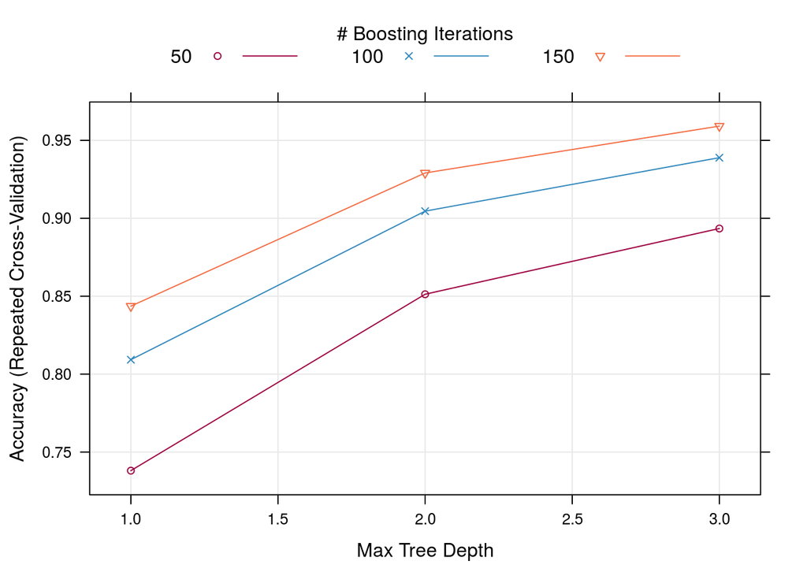

```r
plot(modFit)
```

Important variables of model and Confussion Matrix on prediction of cross validation set :

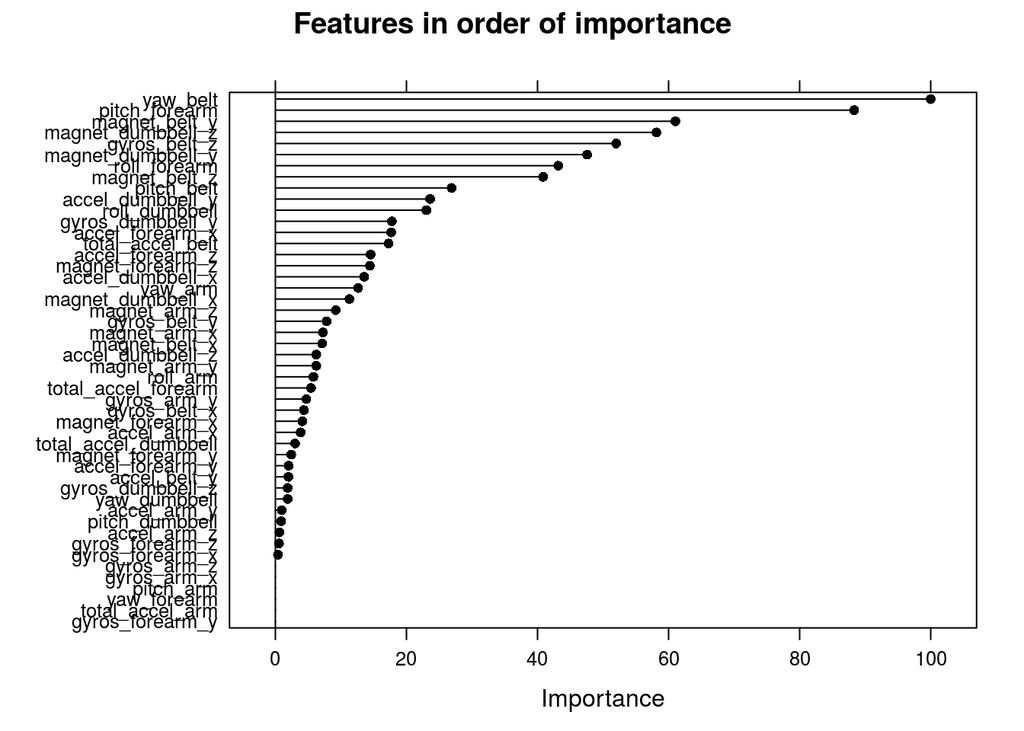

```r
important <- varImp(modFit)
plot(important, main = "Features in order of importance")
```

```r
cvpred<-predict(modFit,trainingCV2)
confusionMatrix(cvpred, trainingCV2$classe)
```

```
## Confusion Matrix and Statistics
##
##           Reference
## Prediction    A    B    C    D    E
##          A 1096   29    0    0    0
##          B   10  714   18    3    6
##          C    8   14  655   29   10
##          D    1    0    9  606    8
##          E    1    2    2    5  697
##
## Overall Statistics
##
##                Accuracy : 0.9605
##                  95% CI : (0.9539, 0.9664)
##     No Information Rate : 0.2845
##     P-Value [Acc > NIR] : < 2.2e-16
##
##                   Kappa : 0.95
##  Mcnemar's Test P-Value : 9.95e-06
##
## Statistics by Class:
##
##                      Class: A Class: B Class: C Class: D Class: E
## Sensitivity            0.9821   0.9407   0.9576   0.9425   0.9667
## Specificity            0.9897   0.9883   0.9812   0.9945   0.9969
## Pos Pred Value         0.9742   0.9507   0.9148   0.9712   0.9859
## Neg Pred Value         0.9929   0.9858   0.9910   0.9888   0.9925
## Prevalence             0.2845   0.1935   0.1744   0.1639   0.1838
## Detection Rate         0.2794   0.1820   0.1670   0.1545   0.1777
## Detection Prevalence   0.2868   0.1914   0.1825   0.1591   0.1802
## Balanced Accuracy      0.9859   0.9645   0.9694   0.9685   0.9818
```

# The prediction

```r
tested <- predict(modFit, test)
tested
```

```
##  [1] B A B A A E D B A A B C B A E E A B B B
## Levels: A B C D E
```

# Creating the submission files:

```r
answers <- as.vector(tested)

pml_write_files = function(x) {
    n = length(x)
    for (i in 1:n) {
        filename = paste0("problem_id_", i, ".txt")
        write.table(x[i], file = filename, quote = FALSE, row.names = FALSE,
            col.names = FALSE)
    }
}

pml_write_files(answers)
```